# lab3 Classwork

Somnath Mukherjee

January 29, 2019

## **EXST 7014 Lab 3: Simple Linear Regression: Regression Diagnostics and Assumptions Test**

Simple linear regression (SLR) is a common analysis procedure, used to describe the significant relationship a researcher presumes to exist between two variables: the dependent (or response) variable, and the independent (or explanatory) variable. This lab will familiarize you with how to perform SLR using the lm command in R.  
You might notice that a single observation that is substantially different from all other observations can make a large difference in the results of your regression analysis. If a single observation (or small group of observations) substantially changes your results, you would want to know about this and investigate further. In this lab exercise, we will use appropriate regression diagnostics to detect influential observations.

In this lab exercise, you will get familiar with and understand the following:  
*1) Use appropriate regression diagnostics to detect influential observations*  
*2) Evaluate the assumptions of SLR using Normality test*

### Lab set-up

```r
#load required packages
#install.packages('olsrr')
#install.packages('here')
#install.packages('car')
library(car)
library(olsrr) #package that runs residual plots and check assumptions for normality
library(here)
library(ggplot2)
```

```r
#read input file
theData = read.table(here('lab3','data','data3.txt'), header = F, stringsAsFactors = T) #use here() function to specify path
colnames(theData)=c("CITY","STATE","LAT","RANGE")
```

The latitude (LAT) and the mean monthly range (RANGE), which is the difference between mean monthly maximum and minimum temperatures, are given for a selected set of US cities. The following program performs a SLR using RANGE as the dependent variable and LAT as the independent variable.  
### Creating a Scatter Plot

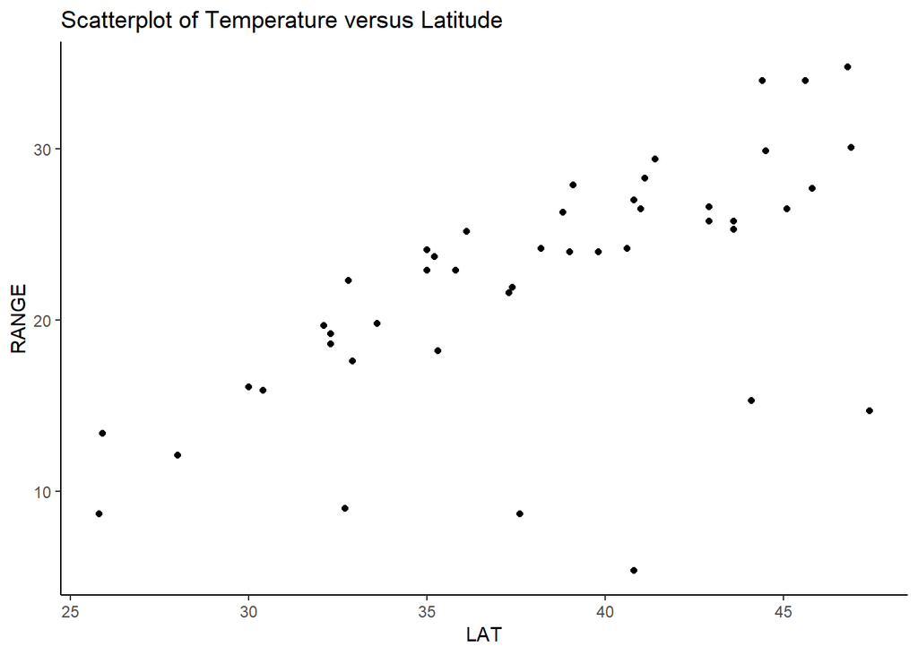

```r
ggplot(data = theData,aes(x = LAT,y = RANGE))+
  geom_point()+
  ggtitle('Scatterplot of Temperature versus Latitude') +
  theme_classic()
```

### Fitting the SLR model

Based on the scatterplot produced above, we assume that an appriopriate regression model relating RANGE and LAT is the linear model given by  
Y = b0 + b1X + e  
where Y is the RANGE, X is the LAT, and e is a random error term that is normally distributed with the mean 0 and the unknown variance.  
b0 is the estimate of the Y-intercept and b1 is the estimate of the slope coeffient.

```r
#fit the model
model1 <‐ lm(RANGE ~ LAT, data = theData)
summary(model1)
```

```
##
## Call:
## lm(formula = RANGE ~ LAT, data = theData)
##
## Residuals:
##      Min       1Q   Median       3Q      Max
## -18.7823  -0.4865   0.8395   3.0765   7.1123
##
## Coefficients:
##             Estimate Std. Error t value Pr(>|t|)
## (Intercept)  -6.4793     5.5481  -1.168    0.249
## LAT           0.7515     0.1438   5.228 4.79e-06 ***
## ---
## Signif. codes:  0 '***' 0.001 '**' 0.01 '*' 0.05 '.' 0.1 ' ' 1
##
## Residual standard error: 5.498 on 43 degrees of freedom
## Multiple R-squared:  0.3886, Adjusted R-squared:  0.3744
## F-statistic: 27.33 on 1 and 43 DF,  p-value: 4.786e-06
```

### Observation Diagonistics[Regression outlier, Leverage obs.,Influential obs.]

**Influential observation** (based on DFFITS,DFBETAS,COOKSD):  
In order for us to get various diagnostics statistics we need to ask R to apply them in the model we have created earlier using the influence.measures command.  
This will list the Hat Diag H, the dffits and dfbetas. It also has cook’s d bar and cov.r. These statistics are usually used to detect possible outliers.  
The package olsrr has a complete analysis for them including great graphics, so we will be using that. For more information on it you can visit:  
<https://cran.r-project.org/web/packages/olsrr/vignettes/influence_measures.html>  
Astericks beside obs. denotes influential obs.

```r
# Get ALL INFLUENCE MEASURES DISCUSSED (DFFITS,DFBETAS,COOKSD,HAT diag)
influence.measures(model1)
```

```
## Influence measures of
##   lm(formula = RANGE ~ LAT, data = theData) :
##
##       dfb.1_   dfb.LAT    dffit cov.r   cook.d    hat inf
## 1   0.026392 -0.023305  0.03248 1.097 5.40e-04 0.0458
## 2   0.069580 -0.061699  0.08464 1.093 3.65e-03 0.0474
## 3   0.002106 -0.001012  0.00755 1.072 2.92e-05 0.0226
## 4   0.187855 -0.280922 -0.67084 0.560 1.66e-01 0.0269   *
## 5  -0.289049  0.252898 -0.36524 0.954 6.37e-02 0.0427
## 6  -0.095110  0.038608 -0.38731 0.803 6.65e-02 0.0224   *
## 7  -0.002108  0.004466  0.01626 1.073 1.35e-04 0.0240
## 8   0.000126  0.004669  0.03245 1.070 5.38e-04 0.0227
## 9  -0.298734  0.282598 -0.31116 1.163 4.88e-02 0.1269   *
## 10 -0.019976  0.018203 -0.02258 1.119 2.61e-04 0.0635
## 11 -0.139515  0.130166 -0.14922 1.144 1.13e-02 0.0930   *
```

[output cut: 34 more lines]

1. To create Cook’s d bar plot and chart we use the following two simple lines with input our model (model 1)

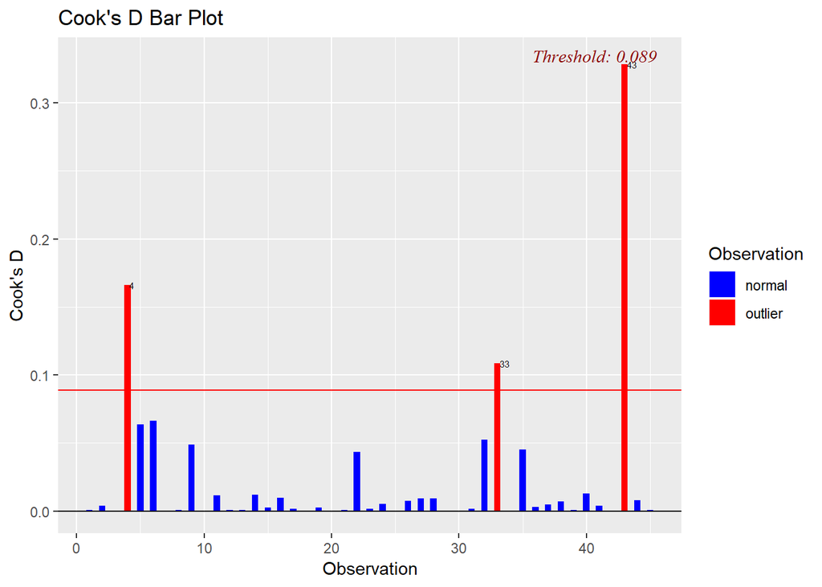

```r
CkDbar=ols_plot_cooksd_bar(model1) # Bar plot
```

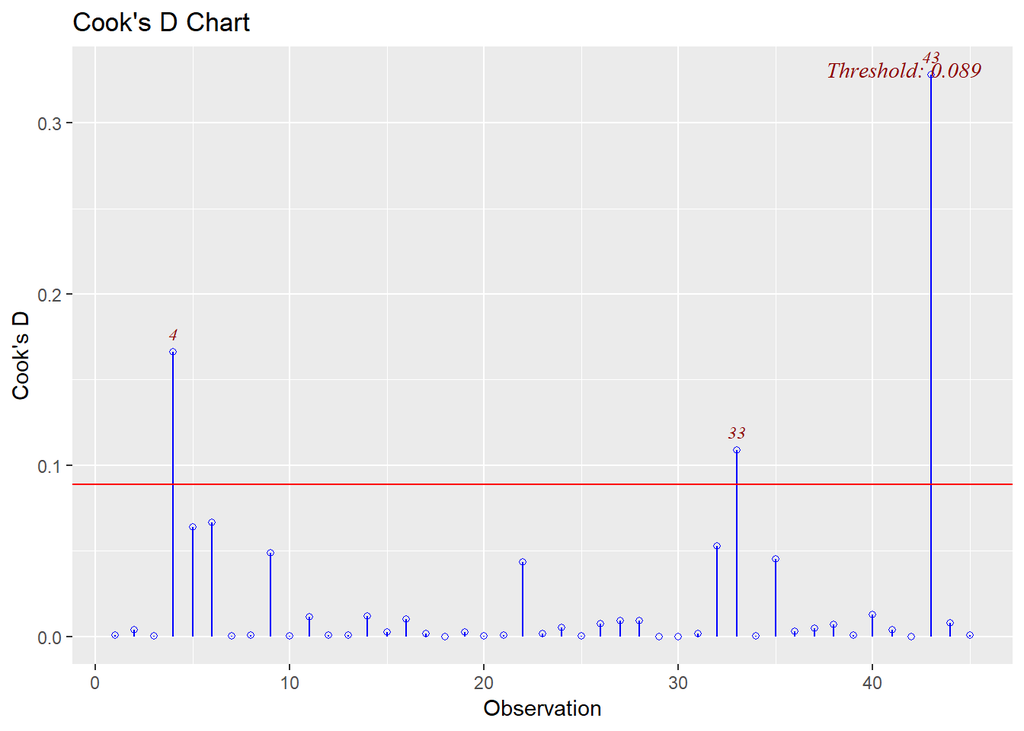

```r
CkDchart=ols_plot_cooksd_chart(model1) # Chart
```

```r
CkDchart$outliers
```

```
## # A tibble: 3 x 2
##   observation cooks_distance
##         <int>          <dbl>
## 1           4          0.166
## 2          33          0.109
## 3          43          0.328
```

That contains the outliers computed by this method.

2. To create the DFBETAs Panel we again ask ols to apply dfbetas analysis on our model as follows:

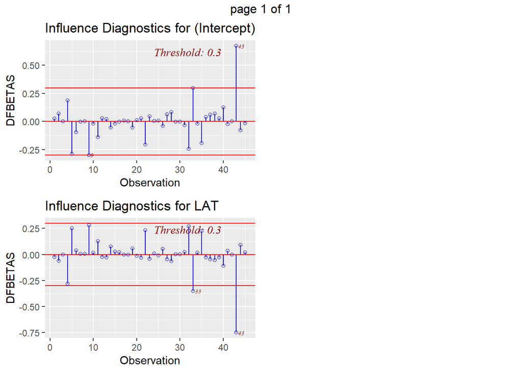

```r
Dfb = ols_plot_dfbetas(model1) #dfbetas analysis
Dfb
```

3. To compute the Dffits one should use:

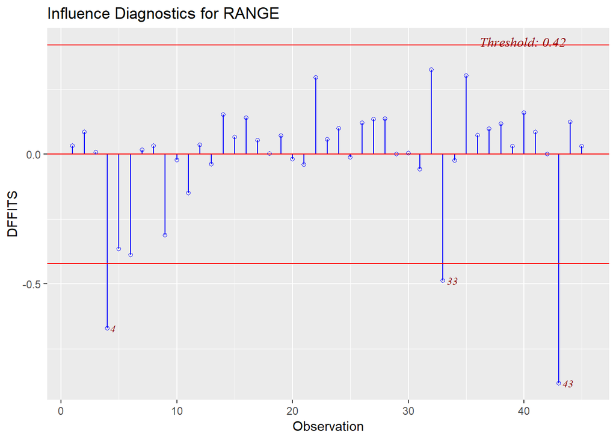

```r
Dff=ols_plot_dffits(model1) #dffites analysis
```

```r
Dff$outlier
```

```
## # A tibble: 3 x 2
##   observation dffits
##         <int>  <dbl>
## 1           4 -0.671
## 2          33 -0.487
## 3          43 -0.882
```

Similarly, you can further explore the Dff list of outputs.  
d) For the studentized Residual Plot the command is

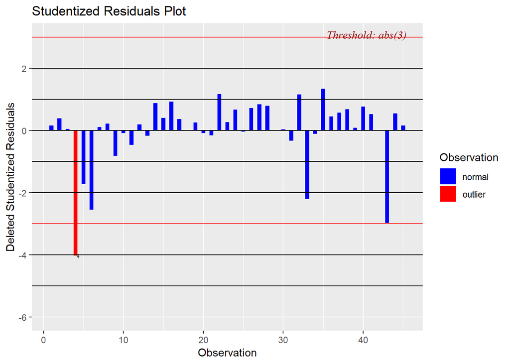

```r
StRes=ols_plot_resid_stud(model1) #Studentized Residual analysis - rstudent
```

```r
StRes$outlier
```

```
## # A tibble: 1 x 2
##   observation stud_resid
##         <int>      <dbl>
## 1           4      -4.03
```

5. For the Standardized Residual Chart you can use

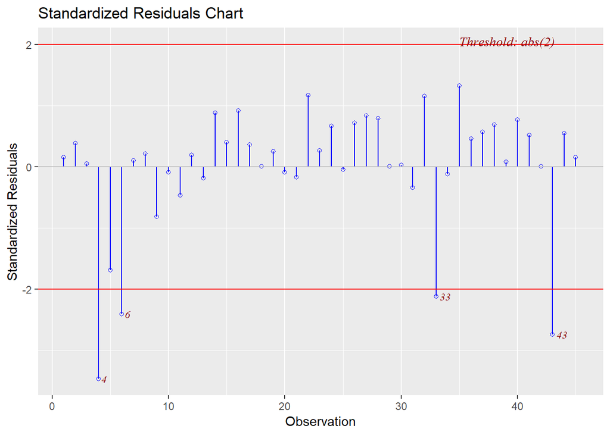

```r
ResSta=ols_plot_resid_stand(model1)
```

```r
ResSta$outlier
```

```
## # A tibble: 4 x 2
##   observation stand_resid
##         <int>       <dbl>
## 1           4       -3.46
## 2           6       -2.41
## 3          33       -2.12
## 4          43       -2.74
```

In order to compute 95% confidence intervals for betas, we need to use the following code:

```r
BetaConfi=confint(model1,level =0.95)
BetaConfi
```

```
##                   2.5 %   97.5 %
## (Intercept) -17.6681689 4.709508
## LAT           0.4616029 1.041418
```

Confint is a multi-purpose function in R, and the argument level=0.95 changes the confidence interval level. The default, if nothing is provided, is 95%.  
To find a confidence interval for the **fitted values** the command is:

```r
Fitconfi=predict(model1, interval="prediction",level=0.95) #For Fitted values- for a single random value
Fitconfi
```

```
##         fit       lwr      upr
## 1  17.79446  6.456652 29.13228
## 2  17.64416  6.297501 28.99082
## 3  21.62717 10.415618 32.83872
## 4  24.18230 12.947104 35.41751
## 5  18.09507  6.774085 29.41605
## 6  21.77747 10.566926 32.98802
## 7  23.43079 12.211530 34.65006
## 8  22.82959 11.617688 34.04148
## 9  12.90964  1.140544 24.67875
## 10 16.36659  4.933113 27.80007
## 11 14.56297  2.972298 26.15364
## 12 18.77143  7.484043 30.05881
## 13 26.28653 14.967260 37.60581
## 14 24.63321 13.384872 35.88155
```

[output cut: 31 more lines]

Again, the level can be adjusted to a desired amount. Also, Fitconfi is a matrix with the corresponding values used for further analysis.  
To find a confidence interval for the **mean values** the command is:

```r
Meanconfi=predict(model1, interval = 'confidence',level=0.95) # For mean values
Meanconfi
```

```
##         fit       lwr      upr
## 1  17.79446 15.422002 20.16693
## 2  17.64416 15.229764 20.05856
## 3  21.62717 19.959394 23.29494
## 4  24.18230 22.362319 26.00229
## 5  18.09507 15.804377 20.38576
## 6  21.77747 20.116474 23.43847
## 7  23.43079 21.711929 25.14966
## 8  22.82959 21.159483 24.49969
## 9  12.90964  8.960677 16.85861
## 10 16.36659 13.572478 19.16071
## 11 14.56297 11.182697 17.94324
## 12 18.77143 16.653019 20.88984
## 13 26.28653 24.004302 28.56877
## 14 24.63321 22.733805 26.53262
```

[output cut: 31 more lines]

Again, the level can be adjusted to a desired amount. Also, Meanconfi is a matrix with the corresponding values used for further analysis.  
Finally, if one wants to find **the confidence interval or the confidence interval for the mean** of a new datapoint with Latitude 10 the following commands will do the trick

```r
predict(model1,data.frame(LAT=10),interval="confidence") #confidence for mean
```

```
##        fit       lwr     upr
## 1 1.035776 -7.296797 9.36835
```

```r
predict(model1,data.frame(LAT=10),interval="prediction") #confidence for fitted
```

```
##        fit       lwr      upr
## 1 1.035776 -12.83322 14.90478
```